# 3-c-1 QA

Emma Wood

16/12/2021

**Run date and time: 2021-12-17 13:11:36**

## Introduction

3-c-1 is a relatively straightforward indicator but it is an easy automation as the data are from Nomis, and there is a calculation that is easier to do without error in R.

This file runs some basic checks and gives information about the update.

## Configurations

The config file contains only two values:

- nomis_employment_link: data from the ‘annual population survey - regional - employment by occupation’ table on Nomis.
- nomis_population_link: data from the ‘population estimates - local authority based by 5 year age band’ table on Nomis.

The details of how these links are generated is given in the README file in the 3-c-1 folder. Links do not need to be updated unless the selections (e.g. of occupations) change.

## Plots

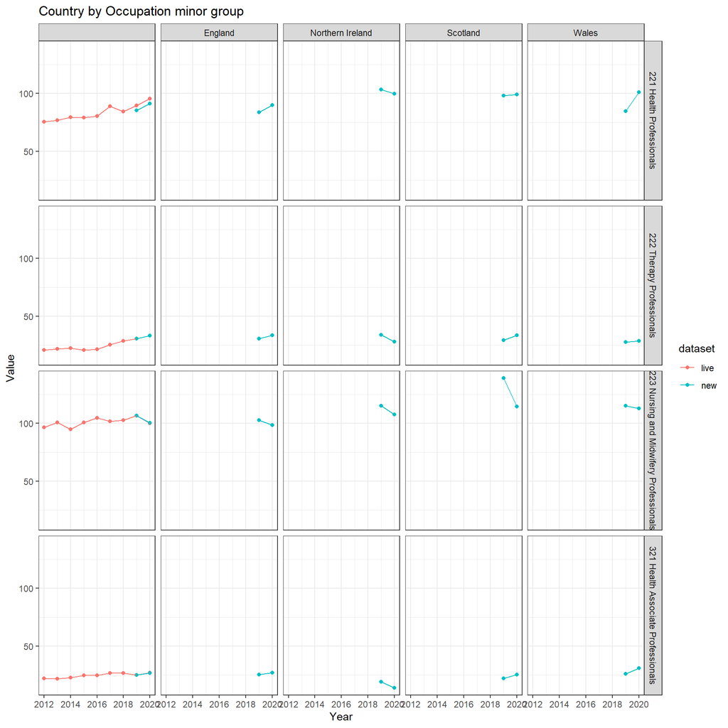

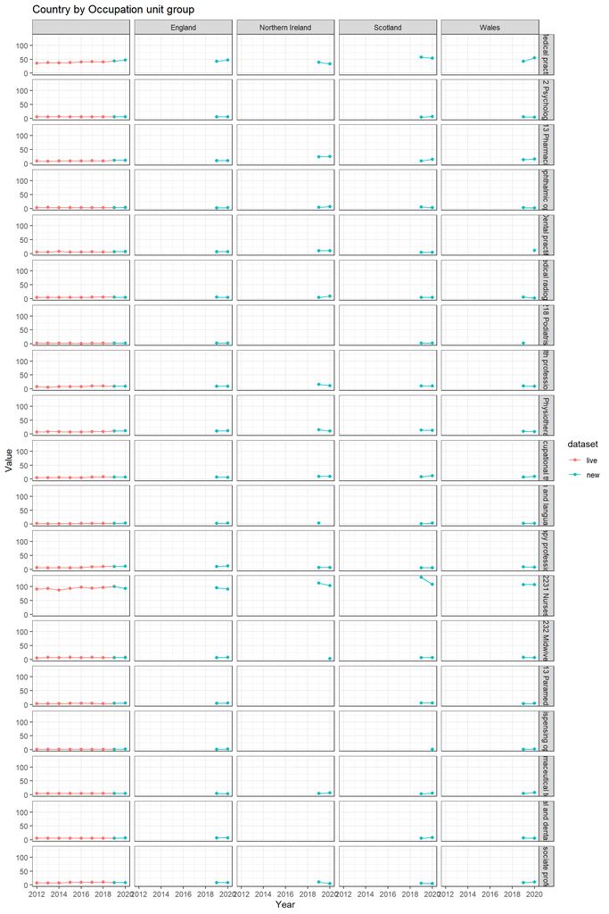

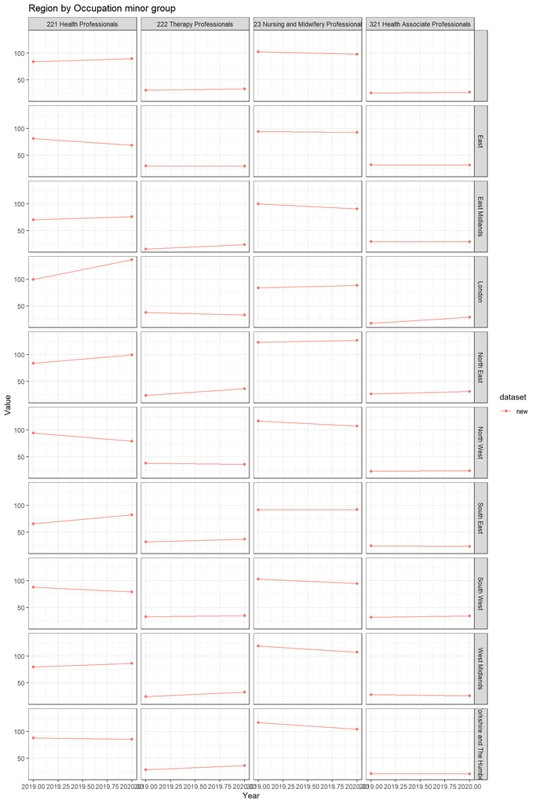

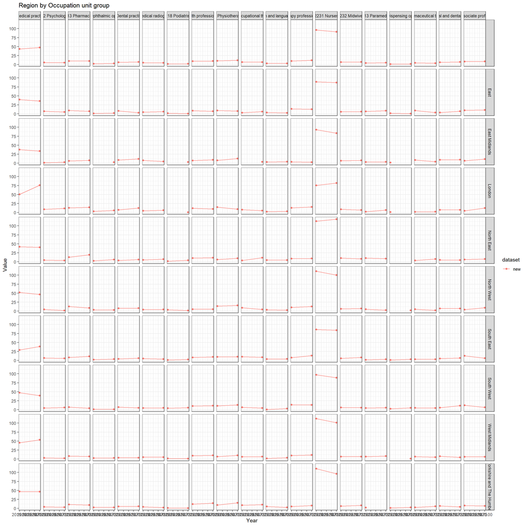